# 9 Data visualization: the grammer of graphics

We start this chapter with an introduction to the grammar of graphics (see Wilkinson (2005) and Wickham (2010)). Many applications are based on this grammar. In R, {ggplot2}, uses the grammar to design plots, Salesforce’s [Tableau](https://www.tableau.com/) is based on this approach as is e.g. {plotnine} in Python. In addition, if you are familiar with plots in Excel or any other spreadsheet and have been experimenting with their options, you’ll recognize many of the components that we’ll discuss here.

In this and subsequent chapters, we will use {[ggplot2](https://ggplot2.tidyverse.org/)} (Chang (2025)) with [cheat sheet](https://github.com/rstudio/cheatsheets/blob/main/data-visualization.pdf)) as the primary package to create visualizations. Some components of {ggplot2} have been supplemented in other packages. For instance, the package {[scales](https://scales.r-lib.org/index.html)) (Wickham, Pedersen, and Seidel (2023)) allows you to scale e.g. the axis or guides (legends), {[ggrepel](https://ggrepel.slowkow.com/)} (Slowikowski (2024)) offers multiple ways to adjust labels in graphs, [{patchwork](https://patchwork.data-imaginist.com/index.html)) (Pedersen (2024b)) allows you to show different types of plots as a group, {[ggthemes](https://jrnold.github.io/ggthemes/index.html)}, (Arnold (2024)) includes many options to generate plots using various styles (e.g. a plot that looks like on shown in The Economist), {[gganimate](https://gganimate.com/index.html)}, (Pedersen and Robinson (2024)) makes it possible to create animations with plots, {[paletteer](https://emilhvitfeldt.github.io/paletteer/index.html)} (Hvitfeldt (2021)) allows you to create many palettes to show, e.g. color scales, both continuous and discreet, {[ggforce](https://ggforce.data-imaginist.com/)} (Pedersen (2024a)} can be used to have more degree of freedom when composing a plot, … In addition to {ggplot2} there are other packages that allow you to create visualizations. {[tidyplots](https://tidyplots.org/)} (Engler (2024)) is an example. You can find a full list of extensions on {[ggplot2](https://exts.ggplot2.tidyverse.org/gallery/)}

{ggplot2} is part of the {tidyverse}. You installed this package in Chapter 1. You can now load {ggplot} and {ggrepel} in memory.

## 9.1 The grammer of graphics

There are 7 components to the grammar of graphics. We will illustrate these components using a graph which plots per capita gdp and life expectancy at birth for 2000. This dataset is included in your `data > raw` folder in the file `life_df.csv`. You can import it using:

```r
life_df <- readr::read_csv(here::here("data", "raw", "life_df.csv"), show_col_types = FALSE)
```

### 9.1.1 The data

First component is the data. Let’s review a sample of the data:

```r
life_df |> slice_sample(n = 5)
```

```
# A tibble: 5 × 8
  iso2c iso3c country           date gdp_capita life_exp     pop region
  <chr> <chr> <chr>            <dbl>      <dbl>    <dbl>   <dbl> <chr>
1 PG    PNG   Papua New Guinea  1976      2076.     55.6 3219829 East Asia & Pa…
2 VU    VUT   Vanuatu           1977        NA      59.2  106200 East Asia & Pa…
3 MH    MHL   Marshall Islands  2000      3041.     63.3   50753 East Asia & Pa…
4 BB    BRB   Barbados          1964      8315.     67.0      NA Latin America …
5 RW    RWA   Rwanda            1979       393.     46.7 4978817 Sub-Saharan Af…
```

The diamonds dataset, which comes with your {gplot2} installation, includes data on the price of diamonds. The dataset has numeric variables, `carat`, `price`, `x`, `y`, `z`, `table` and `depth` and categorical variables `cut`, `color` and `clarity`. For these three categorical variables, the values imply an ordering. For instance, for `cut`, `ideal` is better than `premium`, `premium` is better than `very good`, … .

Recall that tidy data needs to meet at least 3 conditions: all variables are in the columns, all observations in the rows and each cell represents one value. For `life_df` as well as `diamonds` these conditions are satisfied.

### 9.1.2 Aesthetic mappings

A graph shows the values of one of more variables. The aesthetics mappings or aesthetics - the second component of the grammar of graphics - show where (and how) you will see these values in the graph. There are various ways to map these variables. They can be mapped on the horizontal or vertical axis, their values can be shown using a different color (hue) of a dot or line, a different size of a circle or a different shape (circle, square, triangle), opacity (transparency or intensity), a width for a line in a line graph or border of a shape. The x- and y-axis, color, shape, size, alpha (opaticy) or width are examples of aesthitics: they show how a variables is shown in a graph. In other words, aesthetic mappings define where you need to look to find the values for a variable. In Figure 9.1, the variable `gdp_capita` is mapped on the horizontal axis, `life_exp` on the vertical axis, `region` on the color aesthetic and `pop` on the size aesthetic. Note that R doesn’t differentiate between `color` or `colour`.

Figure 9.1: Life expectancy at birth, per capita GDP, region and population, color aesthetic

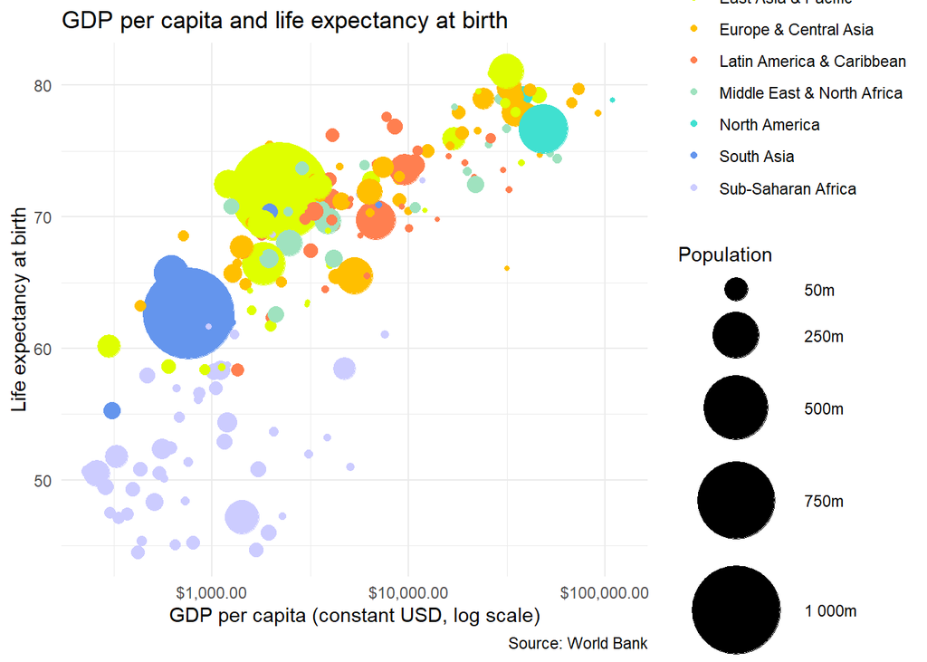

To see the values for variable `gdp_capita` in Figure 9.1, you need to look at the horizontal axis, the values for `life_exp` are shown on the vertical axis. In other words, every per capita GDP - life expectancy pair is identified as a dot where the vertical line starting from the horizontal axis intersects the horizontal line starting from the vertical axis. The `pop` values are shown using the size of the circle (larger circles show larger populations). In other words, the “dots” that represent a per capita GDP - life expectancy pair are shown as a circle where the size of the circle increases with the population of a country. The values for `region` are shown using different colors to fill the circle.

As an alternative, we could have mapped the region on the shape aesthetic. In that case, every different value for `region` is shown by a different shape.

Figure 9.2: Life expectancy at birth, per capita GDP, region and population, shape aesthetic

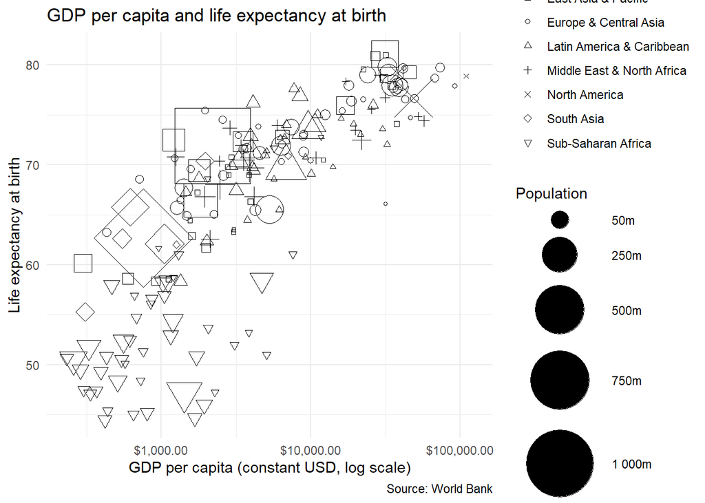

The type of variable determines the aesthetic that you can use: a continuous variable such as per capita GDP or population can be mapped on one of the axis, size, color or transparency. This is not the case for a shape: as there are a limited number of shapes (circle, square, triangle, …), you can only use them to map discrete values. The same holds for the width of a line. Although it would in theory be possible to map a continuous variable on the width of a line, the various widths would hardly be visible.

The shape, color, or size are aesthetics. However, you can also use different shapes, sizes or colors in your graph without an aesthetic mapping. This is done in Figure 9.3. In this graph, per capita GDP is mapped on the horizontal axis and life expectancy on the vertical axis. There are no other variables mapped on the other aesthetics such as color or size. The color, size or shape of a “point” on the graph was chosen for lay out purposes: the color is HEX #FF7F50 and the shape is a square and its size is 5. However, the color, shape or size do not reveal an additional information. In other words, if there no variable mapped on an aesthetic, there it does not reveal any further infomration and looses its meaning or interpretation. Although this could also be the result of an aesthetic mapping because, e.g. all countries in the dataset without missing values are from the same region and would be shown with the same color, usually a single color is inspired by requirements in terms of lay-out, not to represent a value in the graph. A guide allows to interpret differences for an aesthetic (a different colour represents a different region). For an aesthetic, R would usually add a guide or legend. Using color or shape without a mapping this is not the case.

Figure 9.3: Life expectancy at birth and per capita GDP

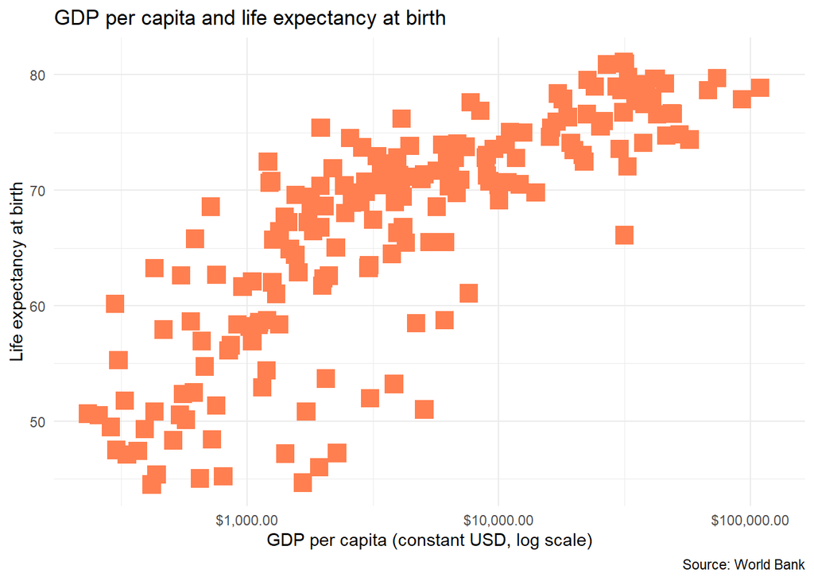

Aesthetic mapping are often determined by the type of the graph (or, the geometry). Figure 9.4 illustrates this using the variable variables `cut`, `clarity` and the number of observations. Here, the choice of the chart - a bar chart - also implies the an aesthetic mapping: given that the bar chart is used to show the number of observations, this variable will be mapped on the x- or -axis. The different values for cut will then be mapped on the other axis while clarity will then be mapped on color. Using a bar char, it wouldn’t be possible to map both clarity and cut on the axis and use another aesthetic to map the number of observations.

Figure 9.4: Cut and clarity: number of observations in the diamonds dataset (sample 10%)

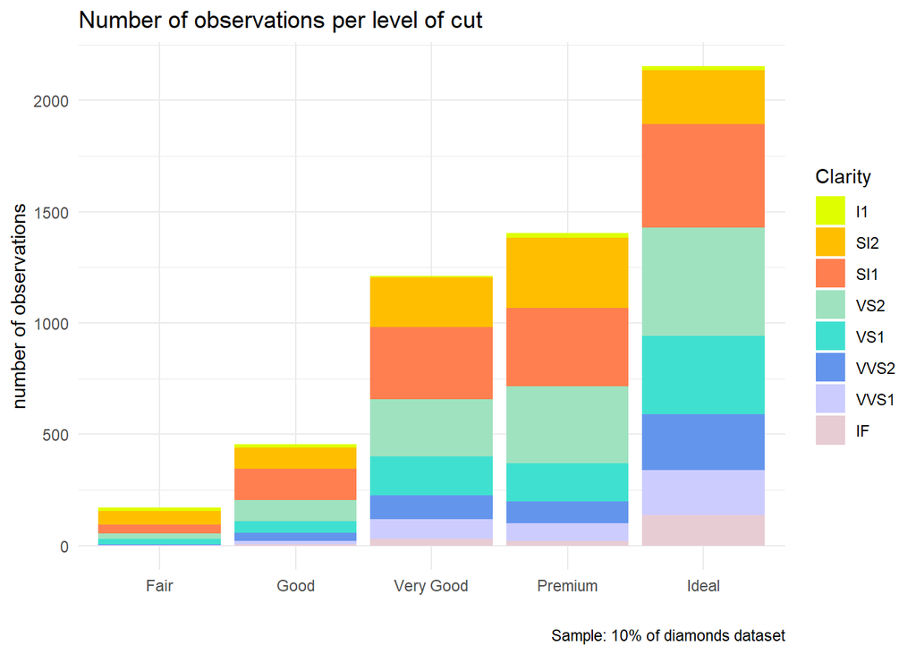

Figure 9.5: Cut and clarity: number of observations in the diamonds dataset (sample 10%)

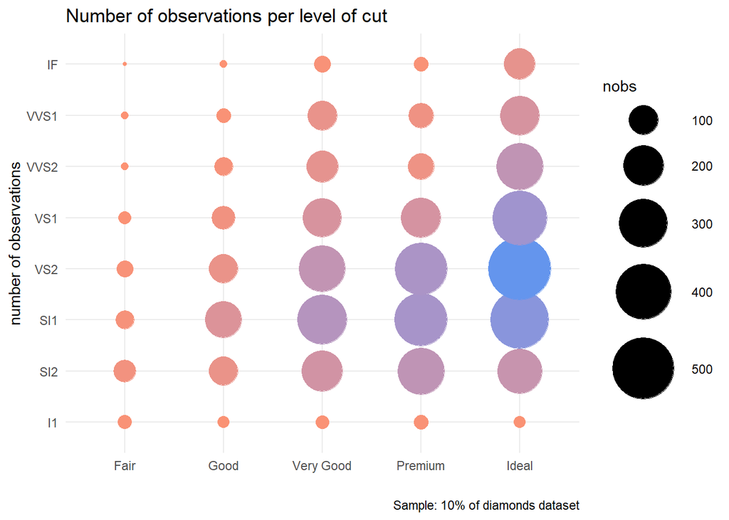

Second, not all aesthetics are suitable for all variables. Suppose you want to map a variable on a shape. Doing so, the values are shown using a dot, a cross, a triangle, a cube, … . There is no order in these shapes: a cube or dot is not bigger or smaller, better or worse, richer or poorer, … than a circle or a filled dot. In other words, using a shape to map an ordinal variable misses to some extent the “point”: your variables imples an order which you want to show with your aesthetic, but the choice of the aesthetic shape has no order. As an alternative, an aesthetic such as color can represent an ordered factor: yellow, orange, red, green, blue, black; lightblue, blue, darkblue, shades of red or grey or, to show temperature: blue to green.

The choice of the aesthetic is important to build good visualizations. People can detect differences in line length, shape, orientation, hue or position with little or no conscious effort. This is called pre-attentive processing and is done very fast and in parallel. These attributes are called pre-attentive attributes. In a data visualization, you should map variables on aesthetics using attributes that a person can identify with little or no effort. In other words, if you use orientation, line length, line width, size, shape, color (hue), opacity (intensity) or spatial position, a data visualization will work much better compared to one where this is not the case. Other attributes are more difficult to process: an area is harder to compare, especially if the differences are subtle. People are usually much better (i.e. faster and with less effort) at detecting differences in position or length than differences in surface area. Likewise, people are usually good at spotting differences in hue but need more effort to interpret differences in intensity. With respect to hue, they are usually much better at identifying differences in a limited set of colors, but require more effort to perceive differences between many shades of the same color. In other words, to compare numeric values, mapping variables on aesthetics that involve positions (e.g. of points in a scatter plot or lines in a line graph) or length (such as the length of a bar in a bar chart) will work better than using variations in color intensity (e.g. a scale from red to green). Although numeric data might include a lot of values, people will process these much after if there is a difference in line length or width or position. This will require much more effort is these variables are mapped on a color aesthetic with a color palette including many shades of green or blue. Mapping categorical variables on color, size of shape aesthetics will make it easier to people (i.e. less conscious effort) to process that graph, as long as the number of colors, shapes or sizes is limited. For examples, see e.g. Stephen Few’s [paper](https://www.perceptualedge.com/articles/ie/visual_perception.pdf). In addition, for some aesthetics, notably color or shape, there are psychological associations that are in part culturally determined. The same holds for some shapes.

### 9.1.3 Geometric object or geometry

The third component is the geometric object or geometry that is used to show the data. In Figure 9.1, that geometric object is a point: for every observations, the graph includes a point that corresponds to the country’s life expectancy and per capita GDP. In other words, if you move left from a specific point, you can read the country’s life expectancy. Moving south from a point shows you its per capita GDP on the horizontal axis. With the color aesthetic, the point also shows you in which region the country is located. The size of the point shows you how many people are living in that country. With the shape aesthetic, the point is shown as a circle, triangle, cross here each shape now represents a region … . Recall that colors, shapes and sizes derive their meaning from the variables mapped onto them. In other words “where” you read “what” is determined by the aesthetic mapping. The geometry determines “how” you show the data. The choice of the aesthetic mapping also “hides” some variables. For instance in Figure 9.1 or Figure 9.2 hide the individual countries. A point represents a unique “per capita GDP - Life expectancy - Region - Populations” quartet. If there are two more more countries with identical values for these variables, they will be shown by one point, with the same color and size (the graph will actually include one point for every country with identical values but as they overlap, will show only one). The geometry in Figure 9.4 is a bar. The height of the bar shows the number of observations, which is mapped on the vertical axis. `cut`, which is mapped on the horizontal axis, shows the level of the cut. `clarity` is mapped on the color aesthetic. Every bar allows you to determine the number of observations, for each level of `cut` from the total height of the bar. You can determine, for every level of `cut` the number of observations for every level of `clarity`. Other geometries are a line, boxplot, an area, a text or a label, … . All these show the data in a particular way. A line graph essentially is a collection of many points and allows you to determine, for any point on the line, the value of the variable mapped on the vertical axis given a value of the variable mapped on the horizontal axis. In other words, you can see a line graph as an extension of point plot. Whereas point plots show the value pairs for all individual observations (i.e. observed values), line plots show the value for the variable on the vertical axis for every possible (both observed and not observed) value on the horizontal axis. Not all geometries include the same set of aesthetics. A line graph needs a variable to map on the horizontal axis and one on the vertical axis. You can show lines for different categorical variables using e.g. a different color for every line representing a different category, a different line type (solid, dotted, dashed, …) or thickness. However, you can’t add a shape aesthetic. A boxplot, which shows the distribution using the e.g. median, 1st and 2rd quartile, 10th and 90th percentile, the mean and the minimum and maximum values will map these values on the vertical axis. In other words, this geometry does not need a variable to map on the vertical axis. For the boxplot geometry, the values on the y-axis are known from the choice of the geometry. However, you can use e.g. the color aesthetic to show a boxplot for different categories. Every plot needs at least one geometry. However, you can combine geometries to create more complex plots.

### 9.1.4 Scales

The fourth components includes the scales. Each mapping is associated with a scale. A scale shows the position of a value on the aesthetic. This scale is related to the type of the variable mapped. For instance, on the horizontal or vertical axis, the scale for a numeric variable shows the position of a value on that axis. In the life expectancy plot, you can see that the vertical axis has a linear scale while the horizontal axis has a log scale. For the vertical axis, the choice of a linear scale implies that the distance between two values will be equal if the difference in life expectancy is equal in absolute terms. With log scales, that is not the case: the distance between two values will be equal is the relative difference in per capita GDP is equal to a factor 10. You can see this in the plot: the difference between 1000 and 10000 is equal to the difference between 10000 and 100000. The scale of the other continues variable, `pop` changes with the size of the population: the size of the dot increases with the size of the population. For the categorical variables `region`, the scale is shown as a different color or shape. If you map a categorical variable on the horizontal axis, the relative position is usually not relevant. For instance, with a bar chart showing average life expectancy at birth for different regions, the distance between these bars is not informative. For numeric variable, the scale is continuous, for categorical variables, it is discrete. If you use a color to represent these scales, the color scale will be continuous for the former (all colors from e.g. green to red) and discrete for the latter (a fixed number of colors in a color palette). In the life expectancy plot, the colors are discrete.

### 9.1.5 Transformations

In a plot, you can show the values of a variable, but also a transformation of these variables. If you show the values without transformations, the values are shown as they appear in the data. In other words, the values that you plot are identical to the values that you find in the data and you plot “identities”. The plot can also show transformations or summaries of the data, e.g. the total number of observations in the data for a given variable or categories of variables (count data), a probability that a variable occurs in the data (a density), a (linear) trend, … . Some geometries, notably those that summarize distributions such as a histogram of box plot, show such transformation by construction. However, you can also add statistical information to e.g. a column or point geometry. In the former for instance, you can show count data, in the second, you can add a linear trend. As an example Figure 9.6 shows a scatterplot (point geometry) with `carat` mapped on the horizontal axis, `price` and the vertical axis and `cut` mapped on the shape aesthetic. The figure also includes a statistical transformation: a smooth line connecting the conditional means for price. The line also include a confidence interval.

Figure 9.6: Carat and price of diamons (sample 10%)

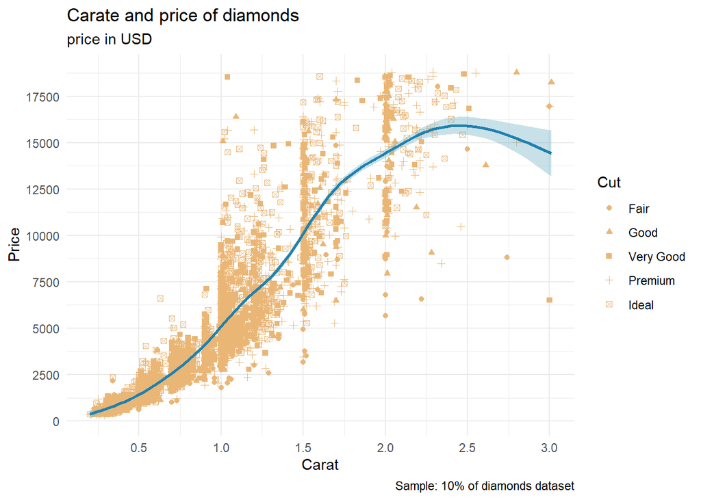

Adding such a smooth line helps to interpret the data: as `carat` rises, so does the `price`. If `carat` low, there is less uncertainty with respect to the price level than when the value for `carat` is high. You can see this as the dispersion of the individual values around the smooth line widens as well as from the wider confidence intervals at higher levels of `carat`. In Figure 9.6, we show both the trendline as well as the individual values. In Figure 9.7, we remove the individual values from the graph. Here, the graph only shows a statistical transformation: the smooth line connecting the conditional mean values.

Figure 9.7: Carat and price of diamons (sample 10%)

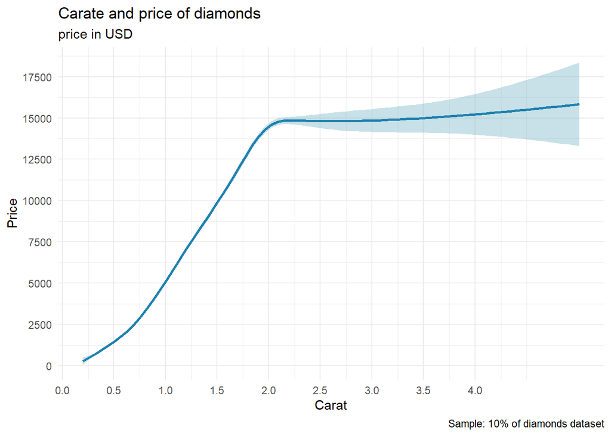

### 9.1.6 Facets

Faceting is another way to show differences between categorical variables. You can map them on an aesthetic, but you can also show them in different plots. Faceting shows the same graph for each level of a categorical variable. Figure 9.8 show an example of faceting. The main graph was already shown in Figure 9.6. In that graph, the level of the cut was shown by mapping that variable on the shape aesthetic. In Figure 9.8, we remove the mapping on the shape aesthetic and show one graph with `carat` mapped on the horizontal axis and `price` on the vertical axes for each level of the variable `cut`. Note that we could have dept the shape aesthetic. However, doing so wouldn’t add any value: each subplot would include the same shape. In addition, not that the trend line is now drawn for each level of `cut`.

Figure 9.8: Carat and price of diamons per cut (sample 10%)

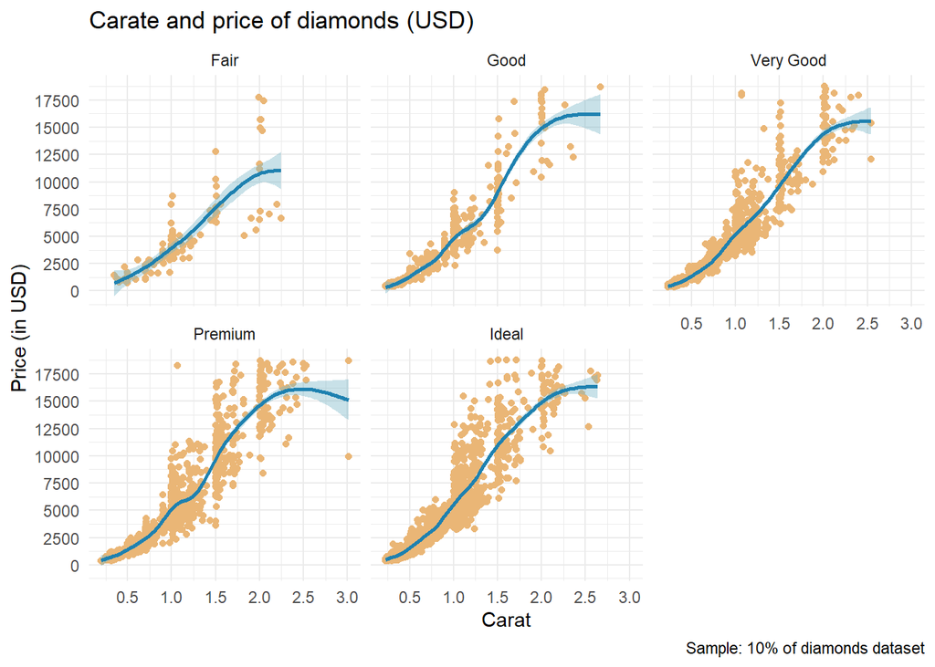

Relative to using a color, shape of size aesthetic, groups are further apart using faceting and there is no overlap. In other words, faceting makes is more difficult to see small differences across groups. Mapping a categorical variable on e.g. a color aesthetic, will show small difference much clearer. Because of this, it is often usefull to add summary annotations or summary statistics that highlight these differences when usin faceting.

### 9.1.7 Coordinate systems

The last component of the grammar of graphics is the coordinate system. There are two types of coordinate systems: linear and non-linear ones. The first includes the default Cartesian coordinate system and is shown in Figure 9.9.

Figure 9.9: Cartesian coordinate system

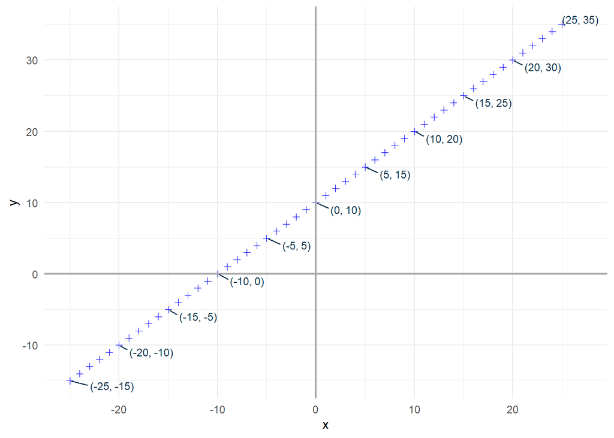

The Cartesian coordinate system represents each point by two numbers (x, y) where x is the x-coordinate and y is the y-coordinate. The former measures the vertical distance from the y-axis and the latter the vertical distance from the x-axis. In Figure 9.9, the point (5, 15) represents a point where x equals 5 and y equals 15. Usually, but that is not always the case, if x and y are related, then the value of the x axis shows the cause and the value on the y-axis the consequence:

$$y = f(x)$$

You can fix the ratio of the length of the x- and y-axis. Doing so with a ratio equal to 1 ensures that both x- and y- axis have equal scales. In other words, 1cm on the x-axis represents the same range as 1cm on the y-axis. Figure 9.10 shows Figure 9.9 but with a fixed ratio equal to 1.

Figure 9.10: Cartesian coordinate system with fixed ratio

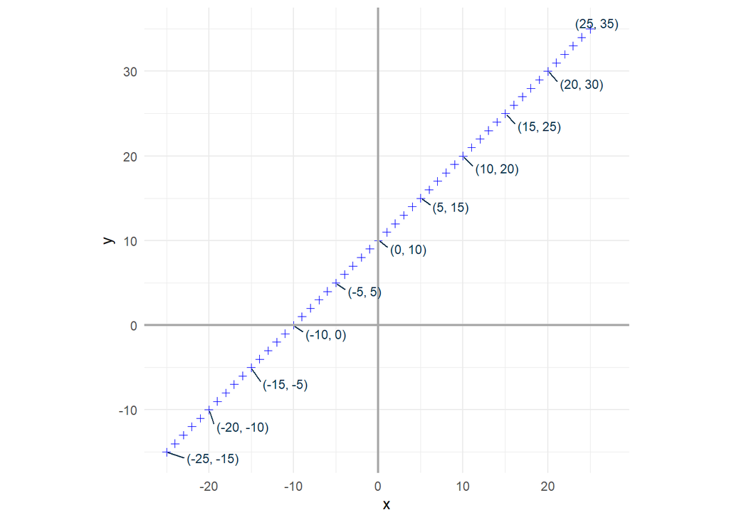

For some graphs, it can be convenient to flip the coordinates. Doing so with a bar or column chart for instance will show the categories on the vertical axis and not on the horizontal axis. Figure 9.11 show Figure 9.4 but the the coordinates flipped.

Figure 9.11: Cut and clarity: number of observations in the diamonds dataset (sample 10%)

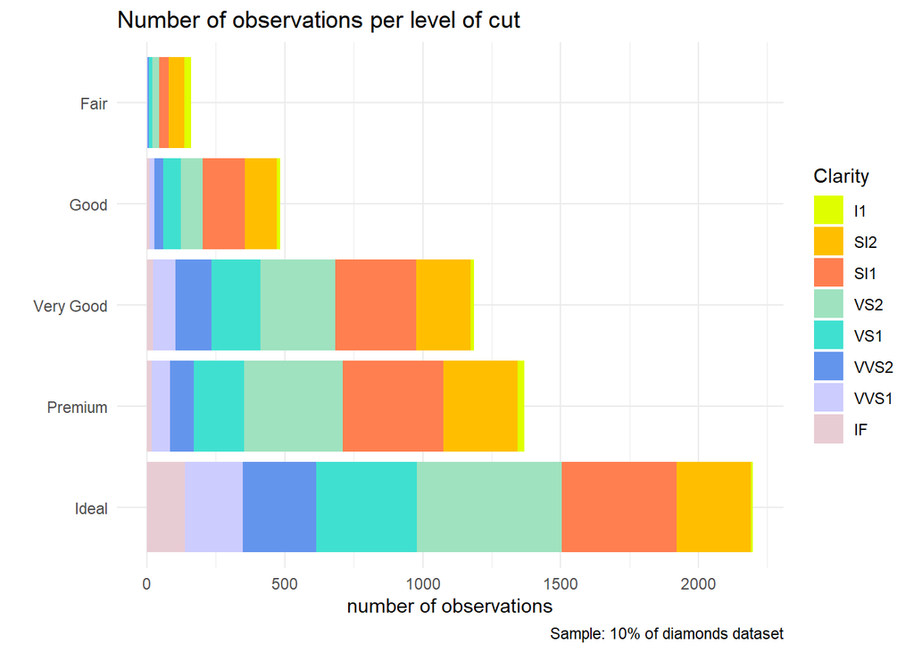

Non-linear coordinate systems change the shape of the geometry. The first non-linear coordinate system results from a transformation. The example of a non-linear coordinate system is the polar coordinate system. Map projections are a third example of a non-linear coordinate systems. An example of the first includes was already shown in Figure 9.1. The x-axis was a log scale. Polar coordinates are used to create pie charts and radar charts. In this system, a point is identified by the points distance from a reference point (the pole) and point’s direction relative to the direction of the polar axis. Moving from a Cartesian coordinate system to a polar one, requires that every point is represented by a distance from a reference point (or radius) and the point’s direction (or angle).

To see how a polar coordinate system changes the shape for the graph, we start from Figure 9.12 which shows a bar chart with the number of observations each category of clarity in the diamonds dataset. The clarity is mapped on the fill aesthetic, the number of observations on the vertical axis. The graph includes one bar: the total number of observations for all diamonds in the sample.

Figure 9.12: Cartesian coordinate system

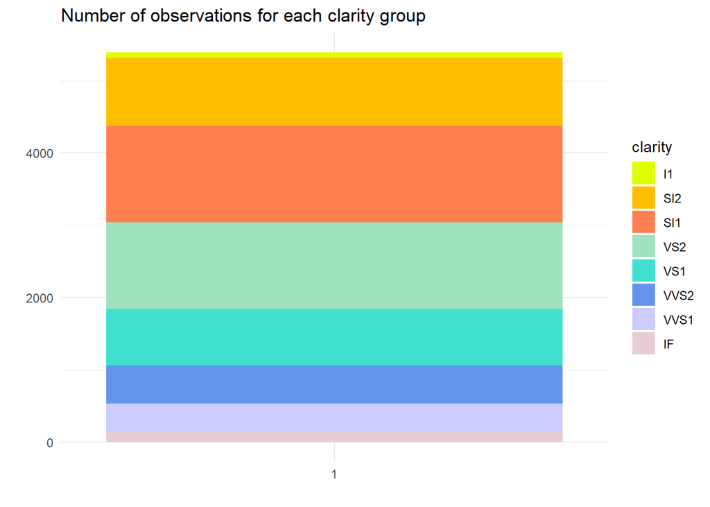

Figure 9.13 includes the same data - the number of diamonds per clarity category - as Figure 9.12. However, now we draw the bar chart in a polar coordinate systems. You can now see that the number of observations is measured as a circle, where each circle has the same distance to the origin (the pole). In other words, they all have the same radius. However angle, the second part of a polar coordinate, is different and reflects the number of observations as a percent of the total number of observations: the more observations, the larger the angle and the large the share that clarity category reflects in the total pie.

Figure 9.13: Polar coordinate system

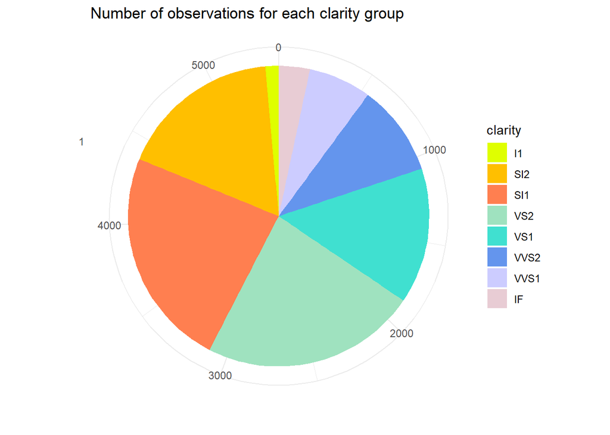

If you compare Figure 9.13 with Figure 9.12, you’ll see that the latter is clearer than the former. Usually, a pie chart doesn’t allow you to see subtle differences in values because these show up as different slices of the pie, not as differences in the height or a bar as in e.g. Figure 9.14.

Figure 9.14: Cartesian coordinate system

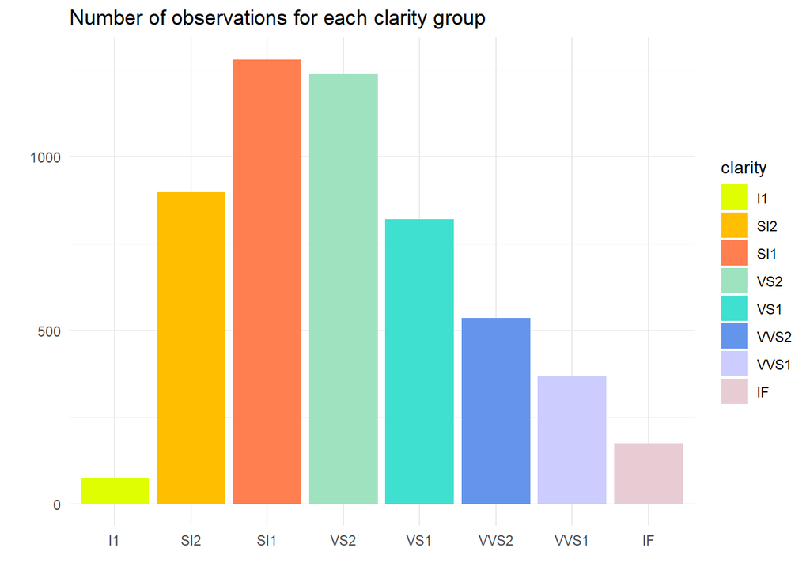

Map projections are a third non-linear coordinate systems. To illustrate, Figure 9.15 shows the map of the world in a Cartesian coordinate system. Because the earth is not a Cartesian 2D frame, this graph does not show the earth as we know it.

Figure 9.15: world map in a Cartesian coordinate system

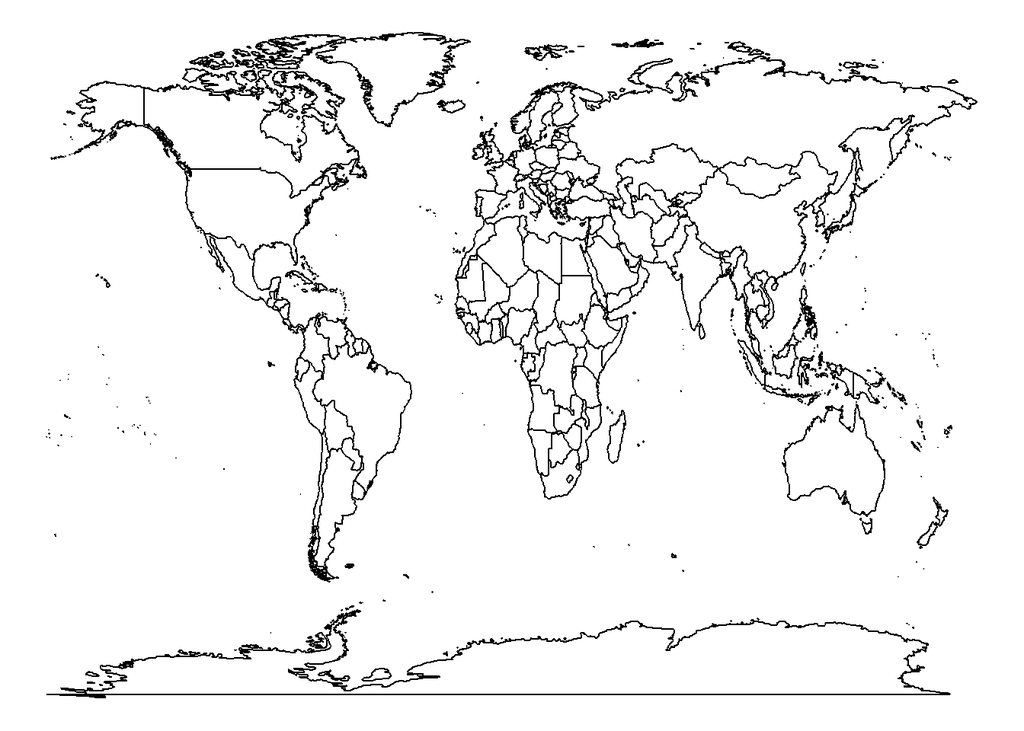

Usually, the map of the earth uses a Mercator projection. In Figure 9.16, we use this projection to plot a map of the earth.

Figure 9.16: world map: Mercator projection

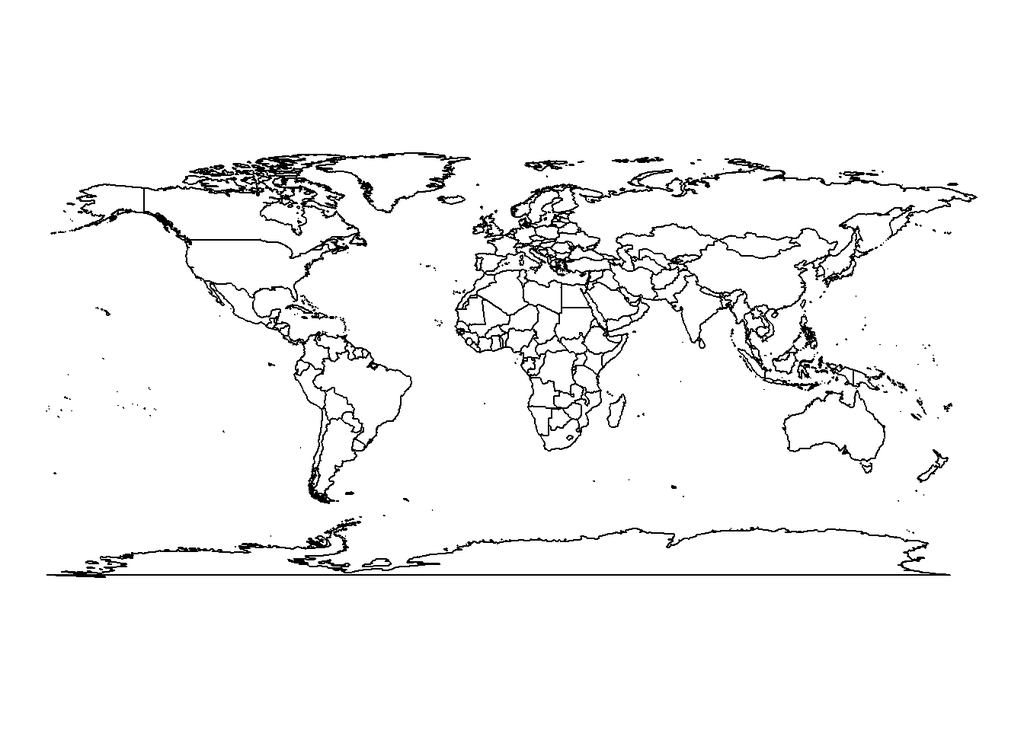

Changing this projection, changes the coordinate system. As there are many projections, there are many ways to show the earth as a map.

## 9.2 The non-data parts of a graph: titles, background, legend

The grammar of graphics deals with the data part of a graph. Graphs also include non data parts: titles or subtitles or captions; the panel background color, borders, major and minor grid lines, aspect ratio; axis titles and labels; a legend including its title, labels and position and, in case of faceting, the margins between facets - both vertical and horizontal - and the text that shows the various categories for each facet. These components are usually set using a theme such as `theme.minimal()` that was used to most plots in this chapter, `theme_base()`, … .

```r
p1
p2
p3
p4
p5
p6
```

Figure 9.17: Non data components of maps

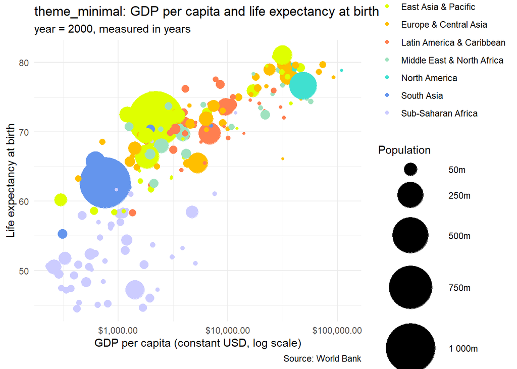

Figure 9.18: Non data components of maps

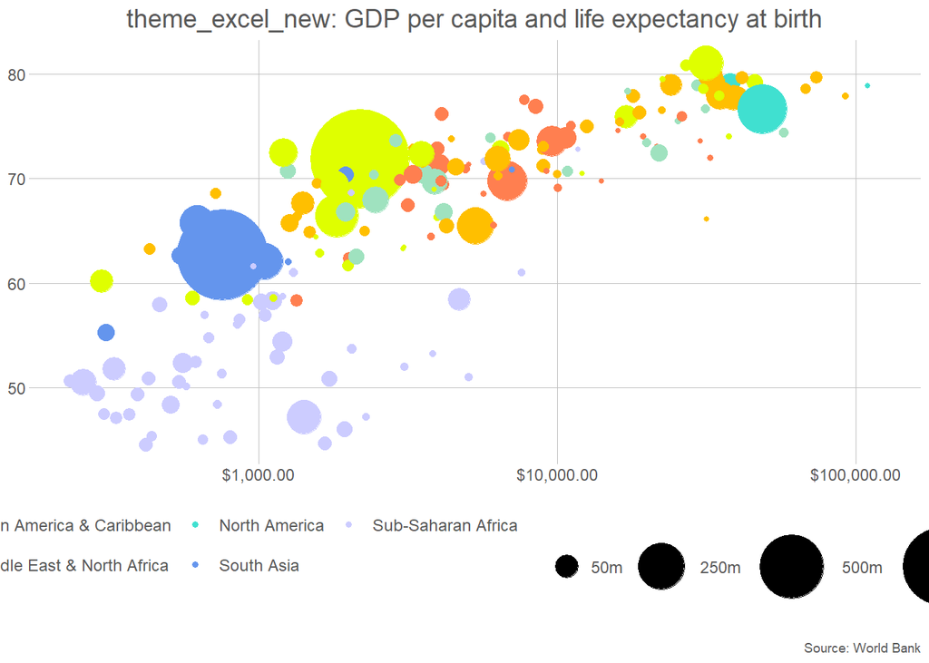

Figure 9.19: Non data components of maps

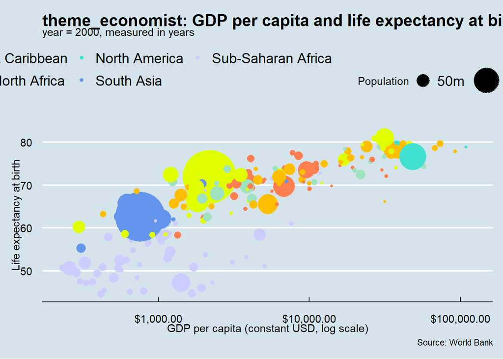

Figure 9.20: Non data components of maps

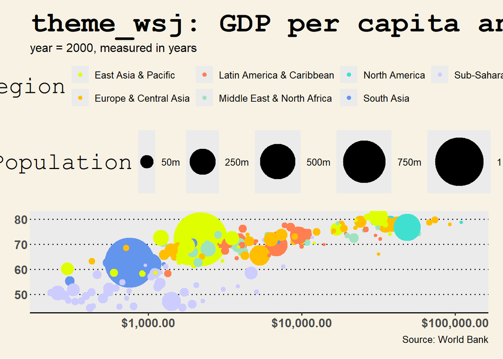

Figure 9.21: Non data components of maps

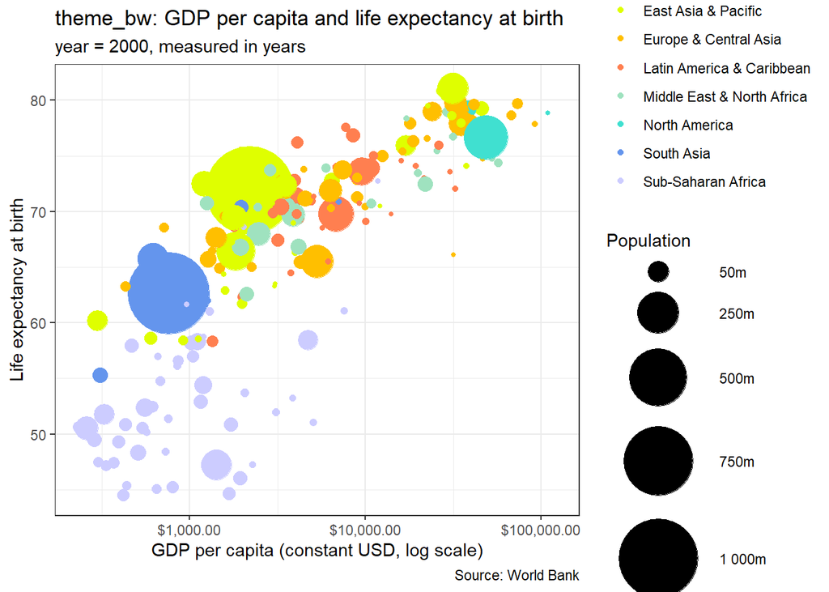

Figure 9.22: Non data components of maps

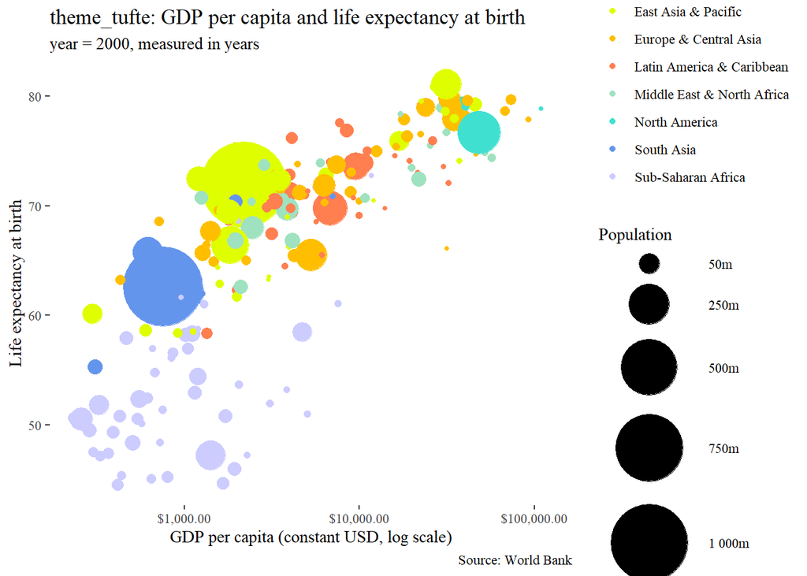

To illustrate, we’ll show Figure 9.1 using 6 themes: `theme_minimal()`, `theme_excel_new()`, `theme_economist()`, `theme_wsj()`, `theme_bw()` and `theme_tufte()`. `theme_economist()` and `theme_wsj()` mimick the graph style of The Economist and the Wall Street Journal. We will cover these layout options more in detail in Chapter 11. {ggplot2} and the many extensions referred to in the introduction allow you to determine the layout of year graph with a extremely high level of detail. Most other packages, e.g. Microsoft Excel, allow you to generate a graph fast but often take a lot of time to get the details of the graph correct. With {ggplot2}, once have your design options fixed, creating a new plot is usually as easy as piping a file into the `ggplot()` function.

Arnold, Jeffrey B. 2024. *Ggthemes: Extra Themes, Scales and Geoms for ’Ggplot2’*. https://jrnold.github.io/ggthemes/.

Chang, Winston. 2025. *R Graphics Cookbook, 2nd Edition*. O’Reilly Media, Sebastopol, CA. https://r-graphics.org/.

Engler, Jan Broder. 2024. “Tidyplots Empowers Life Scientists with Easy Code-Based Data Visualization.” *bioRxiv*. https://doi.org/10.1101/2024.11.08.621836.

Hvitfeldt, Emil. 2021. *Paletteer: Comprehensive Collection of Color Palettes*. https://github.com/EmilHvitfeldt/paletteer.

Pedersen, Thomas Lin. 2024a. *Ggforce: Accelerating ’Ggplot2’*. https://ggforce.data-imaginist.com.

———. 2024b. *Patchwork: The Composer of Plots*. https://patchwork.data-imaginist.com.

Pedersen, Thomas Lin, and David Robinson. 2024. *Gganimate: A Grammar of Animated Graphics*. https://gganimate.com.

Slowikowski, Kamil. 2024. *Ggrepel: Automatically Position Non-Overlapping Text Labels with ’Ggplot2’*.

Wickham, Hadley. 2010. “A Layered Grammar of Graphics.” *Journal of Computational and Graphical Statistics* 19 (1): 3–28. https://doi.org/10.1198/jcgs.2009.07098.

Wickham, Hadley, Thomas Lin Pedersen, and Dana Seidel. 2023. *Scales: Scale Functions for Visualization*. https://scales.r-lib.org.

Wilkinson, Leland. 2005. *The Grammar Op Graphics*. 2nd ed. Springer-Verlag, New York. https://doi.org/https://doi.org/10.1007/0-387-28695-0.